# New York City Motor Vehicle and People Collision Analysis

# **Abstract**

For this project, our group investigated the details of motor vehicle collisions in New York City. Our key findings include: a higher number of crashes occur during the summer months; distracted driving is the most common cause of collisions; car crashes are more frequent than motorcycle crashes, but motorcycle crashes tend to be more fatal; collisions are most likely to occur between 3 PM and 8 PM; and there is a higher density of motor vehicle collisions in tourist-heavy areas of Manhattan compared to the rest of NYC. Understanding the factors that contribute to collisions is essential for implementing effective precautionary measures.

# **Introduction**

This topic was chosen for our project because motor vehicle collisions in highly populated cities can be a significant issue. Almost 400,000 collisions have occurred in the state of New York alone in the year 2023. We wanted to assess the many factors of these collisions to ensure people, pedestrians or drivers, keep them in mind when in New York City. Specifically:

- What time of day do collisions frequently occur?
- What neighborhood are these collisions most likely to happen?
- Are motorcycles or cars more likely to cause fatal injury?
- What is the most likely cause of collisions?
- Do crash rates vary by months?
- Do crashes occur frequently in tourist locations or are they dispersed throughout?

These statistics are important for people to care about so they can take necessary precautions when in New York City to mitigate collisions. This can take form in pedestrians being sure to not jaywalk, or drivers having a heightened awareness and focus on the road.

# **Explanation of Data**

The datasets that were chosen were selected due to their complexity. They consisted of data from 2016 to 2022. The datasets chosen are from the data.gov website. One dataset focused on the details of the crash event in motor vehicle collisions, and the second one focused on details of the people involved in the motor vehicle collisions. The data is collected by the New York Police Department.

While the data is publicly available, individuals involved in the collisions may not have given explicit consent for their information to be used research studies, but no identifiable information is present in the data so it adheres to ethical standards.

[Motor Vehicle Collisions - Crashes - Catalog (data.gov)](https://catalog.data.gov/dataset/motor-vehicle-collisions-crashes)

[Motor Vehicle Collisions - Person - Catalog (data.gov)](https://catalog.data.gov/dataset/motor-vehicle-collisions-person)

The data is freely available for anyone to use and view. At the bottom of the webpage where the dataset was retrieved, it was stated that this data was “Intended for public access and use.” The population of the dataset are the people in New York City, and the sample is the details of the people involved in collisions.

# **Description of Data**

In the first dataset, there were 2.11 million rows and 29 columns. In the second data set, there were 5.44 million rows and 21 columns. Each row represents a collision. The relevant variables are most of the columns, minus a few that were deemed irrelevant upon review, such as duplicates of already established variables that were mostly empty. Missing values in specific columns that were kept were omitted based on how each of us organized our data to answer a specific research question.

# **Cleaning Data Before Working With It**

Before working with our data, it was necessary to clean it and make necessary changes before working with it to solve our research questions. First, the necessary libraries had to be loaded.

```r
library(tigris)
library(dplyr)
library(leaflet)
library(sp)
library(ggmap)
library(broom)
library(httr)
library(sf)
```

```r
library(ggplot2)
library(tidyverse)
library(magick)
library(data.table)
```

After this, we loaded our data by storing the datasets into a `crashes` and `person` variable, named after the specification of their datasets. Then to join the datasets, we first had to modify some variable names so that they can automatically join together. Both datasets had columns that indicated their crash date and time, but were named differently. The columns that indicated the crash date and time in the `crashes` dataset were modified to match how the date and time columns were labeled in the `person` dataset. Therefore, the final merge keys were `CRASH_DATE` , `CRASH_TIME`, and `COLLISION_ID`

```r
crashes <- read_csv("Motor_Vehicle_Collisions_-_Crashes.csv")
person <- read_csv("Motor_Vehicle_Collisions_-_Person.csv")
crashes <- crashes %>%
  rename(CRASH_DATE = `CRASH DATE`,
         CRASH_TIME = `CRASH TIME`)
```

After this, the datasets were merged using a `full_join()` and stored in a variable titled `crashesPerson`. Unnecessary columns then had to be deleted. The `subset()` function was used to do so. From both datasets, the deleted functions consisted of:

- `OFF STREET NAME`
- `VEHICLE TYPE CODE 3`
- `VEHICLE TYPE CODE 4`
- `VEHICLE TYPE CODE 5`
- `EJECTION`
- `PED_LOCATION`
- `PED_ACTION`
- `NUMBER OF CYCLIST KILLED`
- `SAFETY_EQUIPMENT`

```r
crashesPerson <- full_join(crashes, person)
crashesPerson <- subset(crashesPerson, select = -c(`OFF STREET NAME`,
                                                   `VEHICLE TYPE CODE 3`,
                                                   `VEHICLE TYPE CODE 4`,
                                                   `VEHICLE TYPE CODE 5`,
                                                   EJECTION,
                                                   PED_LOCATION,
                                                   PED_ACTION,
                                                   `NUMBER OF CYCLIST KILLED`,
                                                   SAFETY_EQUIPMENT))
```

## **Creating a New Categorical Variable**

To create a new categorical variable, there was a focus on categorizing injury severity. This was done by categorizing a certain number of people injured or killed under:

- “Fatal Injury”
- “Major Injury”
- “Minor Injury”
- “No Injury”

```r
crashesPerson$INJURY_SEVERITY <-  ifelse(crashesPerson$`NUMBER OF PERSONS KILLED` > 0, "Fatal Injury",
  ifelse(crashesPerson$`NUMBER OF PERSONS INJURED` > 5, "Major Injury",
    ifelse(crashesPerson$`NUMBER OF PERSONS INJURED` > 0, "Minor Injury","No Injury"
    )
  )
)

head(crashesPerson$INJURY_SEVERITY,7)
```

```
## [1] "Minor Injury" "Minor Injury" "Minor Injury" "Minor Injury" "Minor Injury"
## [6] "Minor Injury" "No Injury"
```

## **Creating a New Numerical Variable**

To create a new numerical variable, there was a focus on quantifying the total number of injuries of that collision

```r
crashesPerson$TOTAL_INJURIES <- crashesPerson$`NUMBER OF PERSONS INJURED` +
  crashesPerson$`NUMBER OF PEDESTRIANS INJURED` +
  crashesPerson$`NUMBER OF CYCLIST INJURED` +
  crashesPerson$`NUMBER OF MOTORIST INJURED`

head(crashesPerson$TOTAL_INJURIES,7)
```

```
## [1] 4 4 4 4 2 2 0
```

## **Creating a Summarization Table**

For the summarization table, there was a focus on finding the emotional status of each person relative to their position in the car.

```r
emotionPosition <- crashesPerson %>%
  group_by(EMOTIONAL_STATUS, POSITION_IN_VEHICLE) %>%
  summarize(totalPeople = n(),
            totalInjuries = sum(TOTAL_INJURIES, na.rm = TRUE),
            totalFatalities = sum(`NUMBER OF PERSONS KILLED`, na.rm = TRUE),
            avgInjuriesPerPerson = mean(TOTAL_INJURIES, na.rm = TRUE),
            avgFatalitiesPerPerson = mean(`NUMBER OF PERSONS KILLED`, na.rm = TRUE),
            .groups = 'drop') %>%
  arrange(EMOTIONAL_STATUS,POSITION_IN_VEHICLE)

head(emotionPosition,3)
```

```
## # A tibble: 3 × 7
##   EMOTIONAL_STATUS POSITION_IN_VEHICLE totalPeople totalInjuries totalFatalities
##   <chr>            <chr>                     <int>         <dbl>           <dbl>
## 1 Apparent Death   Any person in the …           6            62               9
## 2 Apparent Death   Does Not Apply               10             2               5
## 3 Apparent Death   Driver                      848           745             694
## # ℹ 2 more variables: avgInjuriesPerPerson <dbl>, avgFatalitiesPerPerson <dbl>
```

# **Research Questions**

## **What time of day do collisions frequently occur?**

The main variable that was used was CRASH_TIME. This was the only variable needed for this particular research question because it was looking into the frequency of what time of day that car crashes occurred. To process the data, I had to extract each value out of CRASH_TIME and change them into a numeric value. Basically, I grabbed hour and minute and changed them into numbers that could be plotted on a bar graph. A bar graph was chosen because I was working exclusively with numerical values. For the sample, I used all possible observations in order to gather the most accurate conclusion about which time of day car crashes occur the most often.

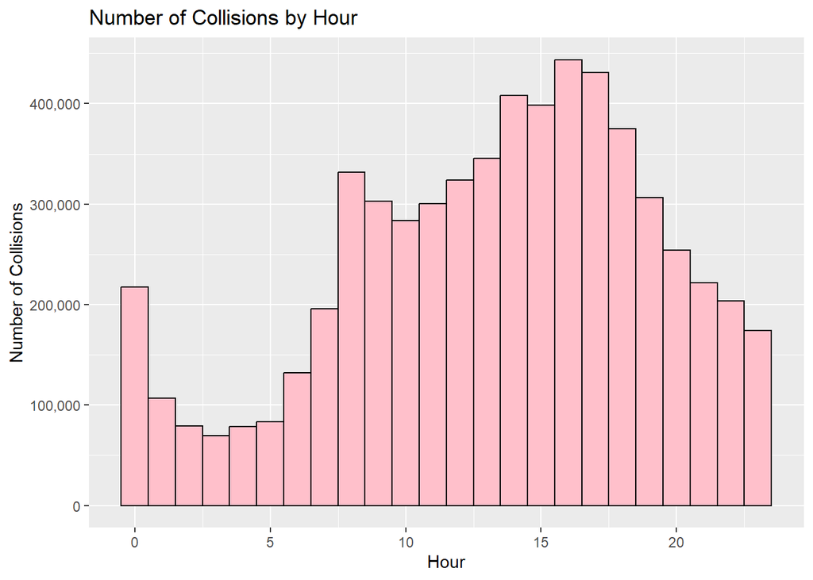

```r
crashesPerson$CRASH_TIME <- as.character(crashesPerson$CRASH_TIME)
crashesPerson$HOUR <- as.numeric(sub(":.*", "", crashesPerson$CRASH_TIME))
crashesPerson$MINUTE <- as.numeric(sub(".*:", "", crashesPerson$CRASH_TIME))

ggplot(crashesPerson, aes(x = HOUR)) +
  geom_histogram(bins = 24, fill = "pink", color = "black") +
  labs(title = "Number of Collisions by Hour",
       x = "Hour",
       y = "Number of Collisions") +
  scale_y_continuous(labels = function(x) format(x, big.mark = ",", scientific = FALSE))
```

### **Trade-Offs:**

While this graph does give the time of day that collisions are mostly to occur, it could be more specific to include other variables. Another thing to consider is the accuracy of the data. The dataset fails to mention fully how it went about collecting the crash time, meaning the accuracy of it can be questioned. To add onto this, another question surfaces: were there unrecorded crashes? However, with this question, these unrecorded crashes would likely not be enough to significantly affect the data.

### **Findings:**

It is likely that many people commute from work around 3-8pm, making the likelihood of accidents increase with the amount of vehicles on the road. Pushing into the later evening hours, drivers may have a harder time navigating through the roads. For the outlier at midnight, this may be a result of reckless driving as people are often going out drinking or partying at these hours. Another factor that could contribute to this figure is decreased visibility at night, making it all the more likely for drivers to get into accidents. The limitation from these findings is that my graph fails to mention the specific day that collisions occurred, which would provide more conclusive results. For the future, a graph that includes the time of day could tell a story of whether these crashes are occurring on weekends or working days.

In short, collisions occurred most often at the **3pm to 8pm** mark with the peak being at 4pm. Additionally, collisions have a small, but significant peak at midnight. For future road safety in NYC, the government can look at this data to note which time of day that the frequency of collisions take place the most and go from there to improve road conditions. Drivers can also look at this data to figure out which time of day to be most vigilant as well.